# Tenth Week: Principal Component Analysis and Factor Analysis

PCA Stock, image, …

Erfan Hosseini _ 93101373

2018-05-17 17:42:08

> با استفاده از داده های OHLCV شرکت های تشکیل دهنده شاخص s&p500 و همچنین داده مربوط به شاخص های اقتصادی به سوالات زیر پاسخ دهید.

```r
rm(list = ls())
library(dplyr)
library(ggplot2)
library(highcharter)
library(readr)
library(stringr)
library(pracma)
library(data.table)
library(car)
## Part 1
pathData = "~/R/HW9/hw_09/Data/stock_dfs"
path = "~/R/HW9/hw_09/Data"
names = list.files(pathData, pattern = "*.csv")
stat = read_csv(paste(path, "constituents.csv", sep = '/'))
yearlyGainRep = data.frame()
thirteenDay = data.frame()
for(i in names){
    crt = read_csv(paste(pathData, i, sep = '/'))
    crt %>% mutate(name = substr(i, 1, nchar(i)-4), year = substr(Date, 1, 4)) -> crt
    crt %>% group_by(year) %>% summarise(gain = (tail(Close, 1) - Open[1]) / Open[1] * 100, Symbol = name[1]) -> rep
    yearlyGainRep = bind_rows(yearlyGainRep, rep)
    crt %>% filter(substr(Date, 9, 10) == "13") -> thirteens
    thirteenDay =  bind_rows(thirteenDay, thirteens)
}
```

۱. چه شرکتی رکورددار کسب بیشترین سود در بازه یکساله، دو ساله و پنج ساله می باشد؟ این سوال را برای بخش های مختلف مورد مطالعه قرار دهید و رکورددار را معرفی کنید. (برای این کار به ستون sector داده constituents مراجعه کنید.) برای هر دو قسمت نمودار سود ده شرکت و یا بخش برتر را رسم نمایید.

We can see the list of stocks with highest yearly gain in each sector in table below:

```r
yearlyGainRep = yearlyGainRep %>% full_join(stat) %>% na.omit()
oneYearRep = yearlyGainRep %>% group_by(Sector) %>% arrange(desc(gain)) %>% slice(1:1)
oneYearRep = oneYearRep %>% select(Symbol, Name, Sector, Gain = gain)
print(oneYearRep)
```

```
## # A tibble: 11 x 4
## # Groups:   Sector [11]
##    Symbol Name                                Sector                  Gain
##    <chr>  <chr>                               <chr>                  <dbl>
##  1 KMX    Carmax Inc                          Consumer Discretiona…  478.
##  2 MNST   Monster Beverage                    Consumer Staples       332.
##  3 WMB    Williams Cos.                       Energy                 255.
##  4 AIG    American International Group, Inc.  Financials            1810.
##  5 LH     Laboratory Corp. of America Holding Health Care           4673.
##  6 AAL    American Airlines Group             Industrials            160.
##  7 FLIR   FLIR Systems                        Information Technolo…  588.
##  8 MOS    The Mosaic Company                  Materials              337.
##  9 GGP    General Growth Properties Inc.      Real Estate            782.
## 10 T      AT&T Inc.                           Telecommunication Se…   46.0
## 11 AES    AES Corp                            Utilities              208.
```

We can see the plot of 10 most profitable stocks in figure below:

```r
symbolList = yearlyGainRep %>% select(Symbol) %>% distinct() %>% unlist()
top10yearly = yearlyGainRep %>% arrange(desc(gain)) %>% head(10)
hchart(top10yearly, hcaes(x = Name, y = gain), type = 'bar')
```

[interactive chart not shown]

We can see the list of stocks with highest 2 year gain in each sector in table below:

```r
twoYearGainRep = data.frame()
for (i in symbolList) {
    crt = yearlyGainRep %>% filter(Symbol == i)
    if(length(crt$year) >= 3){
        crt %>% mutate(gain = movavg(gain, 2, "s")*2) %>% slice(2:n()) -> crt
        year = as.numeric(crt$year)
        prevYear = as.character(year-1)
        crt$year = paste(prevYear, year, sep = "-")
        crt$year = substr(crt$year, 1, 9)
        twoYearGainRep = bind_rows(twoYearGainRep, crt)
    }
}
twoYearRep = twoYearGainRep %>% group_by(Sector) %>% arrange(desc(gain)) %>% slice(1:1)
print(twoYearRep)
```

```
## # A tibble: 11 x 5
## # Groups:   Sector [11]
##    year        gain Symbol Name                                Sector
##    <chr>      <dbl> <chr>  <chr>                               <chr>
##  1 2000-2001  553.  KMX    Carmax Inc                          Consumer D…
##  2 2004-2005  443.  MNST   Monster Beverage                    Consumer S…
##  3 2003-2004  320.  WMB    Williams Cos.                       Energy
##  4 2009-2010 1898.  AIG    American International Group, Inc.  Financials
##  5 2000-2001 4619.  LH     Laboratory Corp. of America Holding Health Care
##  6 2012-2013  244.  AAL    American Airlines Group             Industrials
##  7 2001-2002  617.  FLIR   FLIR Systems                        Informatio…
##  8 2006-2007  393.  CF     CF Industries Holdings Inc          Materials
##  9 2009-2010  815.  GGP    General Growth Properties Inc.      Real Estate
## 10 2006-2007   62.5 T      AT&T Inc.                           Telecommun…
## 11 2003-2004  253.  AES    AES Corp                            Utilities
```

We can see the top 10 most profitable companies in 2 year period in figure below:

```r
top10twoYear = twoYearGainRep %>% arrange(desc(gain)) %>% group_by(Symbol) %>% slice(1:1) %>% arrange(desc(gain)) %>% head(10)
hchart(top10twoYear, hcaes(x = Name, y = gain), type = 'bar')
```

[interactive chart not shown]

We can see the list of stocks with highest 5 year gain in each sector in table below:

```r
fiveYearGainRep = data.frame()
for (i in symbolList) {
    crt = yearlyGainRep %>% filter(Symbol == i)
    if(length(crt$year) >= 6){
        crt %>% mutate(gain = movavg(gain, 5, "s")*5) %>% slice(5:n()) -> crt
        year = as.numeric(crt$year)
        prevYear = as.character(year-4)
        crt$year = paste(prevYear, year, sep = "-")
        crt$year = substr(crt$year, 1, 9)
        fiveYearGainRep = bind_rows(fiveYearGainRep, crt)
    }
}
fiveYearRep = fiveYearGainRep %>% group_by(Sector) %>% arrange(desc(gain)) %>% slice(1:1)
print(fiveYearRep)
```

```
## # A tibble: 11 x 5
## # Groups:   Sector [11]
##    year        gain Symbol Name                                Sector
##    <chr>      <dbl> <chr>  <chr>                               <chr>
##  1 2000-2004  605.  KMX    Carmax Inc                          Consumer D…
##  2 2001-2005  552.  MNST   Monster Beverage                    Consumer S…
##  3 2003-2007  412.  WMB    Williams Cos.                       Energy
##  4 2009-2013 1927.  AIG    American International Group, Inc.  Financials
##  5 2000-2004 4637.  LH     Laboratory Corp. of America Holding Health Care
##  6 2010-2014  415.  AAL    American Airlines Group             Industrials
##  7 2003-2007  701.  AKAM   Akamai Technologies Inc             Informatio…
##  8 2006-2010  467.  CF     CF Industries Holdings Inc          Materials
##  9 2009-2013  841.  GGP    General Growth Properties Inc.      Real Estate
## 10 2003-2007   49.0 T      AT&T Inc.                           Telecommun…
## 11 2003-2007  304.  AES    AES Corp                            Utilities
```

```r
top10fiveYear = fiveYearGainRep %>% arrange(desc(gain)) %>% group_by(Symbol) %>% slice(1:1) %>% arrange(desc(gain)) %>% head(10)
hchart(top10fiveYear, hcaes(x = Name, y = gain), type = 'bar')
```

[interactive chart not shown]

۲. یک اعتقاد خرافی می گوید خرید سهام در روز سیزدهم ماه زیان آور است. این گزاره را مورد ارزیابی قرار دهید.

We will use t test to see wether mean of gain is smaller than zero or not.

```r
thirteenDay = thirteenDay %>% mutate(gain = (Close - Open) / Open *100)
t.test(thirteenDay$gain, mu = 0, alternative = 'greater')
```

```
##
##  One Sample t-test
##
## data:  thirteenDay$gain
## t = 11.568, df = 65541, p-value < 2.2e-16
## alternative hypothesis: true mean is greater than 0
## 95 percent confidence interval:
##  0.08391949        Inf
## sample estimates:
##  mean of x
## 0.09783038
```

As we can see in the test result, 13th is actually a good day to trade.

۳. رکورد بیشترین گردش مالی در تاریخ بورس برای چه روزی بوده است و چرا!!!

```r
entire = data.frame()
for(i in names){
    crt = read_csv(paste(pathData, i, sep = '/'))
    crt %>% mutate(name = substr(i, 1, nchar(i)-4), year = substr(Date, 1, 4)) -> crt
    entire = crt %>% mutate(cap = Volume * abs(Close - Open)/2) %>% bind_rows(entire)
}
capRep = entire %>% group_by(Date) %>% summarise(cap = sum(cap)) %>% arrange(desc(cap)) %>% head(5)
print(capRep)
```

```
## # A tibble: 5 x 2
##   Date                cap
##   <date>            <dbl>
## 1 2008-10-10 12971799214.
## 2 2008-09-29 12832322664.
## 3 2008-10-09 11302376669.
## 4 2008-10-07 10398814239.
## 5 2008-10-14  8925963889.
```

The day with most turnover is 10th of October 2008 which is the same time as US financial crisis.

۴. شاخص AAPL که نماد شرکت اپل است را در نظر بگیرید. با استفاده از رگرسیون خطی یک پیش کننده قیمت شروع (open price) بر اساس k روز قبل بسازید. بهترین انتخاب برای k چه مقداری است؟ دقت پیش بینی شما چقدر است؟

```r
appleData = entire %>% filter(name == "AAPL") %>% select(Date, Open)
k = 5
columns = colnames(appleData)
for (i in 1:k){
    eval(parse(text = paste0('appleData$colum', i, ' <- 0')))
    appleData[,i+2] = shift(appleData$Open, i)
    columns[[i+2]] = paste("Daysago", i, sep = "_")
}
colnames(appleData) = columns
appleData = appleData %>% slice(k+1:n())
fit = lm(data = appleData, formula = Open ~ Daysago_1 + Daysago_2 + Daysago_3)
summary(fit)
```

```
##
## Call:
## lm(formula = Open ~ Daysago_1 + Daysago_2 + Daysago_3, data = appleData)
##
## Residuals:
##     Min      1Q  Median      3Q     Max
## -556.35   -1.10   -0.07    1.32   53.40
##
## Coefficients:
##              Estimate Std. Error t value Pr(>|t|)
## (Intercept) 0.2709642  0.2104948   1.287    0.198
## Daysago_1   0.9695413  0.0153052  63.347   <2e-16 ***
## Daysago_2   0.0284989  0.0213126   1.337    0.181
## Daysago_3   0.0003996  0.0153050   0.026    0.979
## ---
## Signif. codes:  0 '***' 0.001 '**' 0.01 '*' 0.05 '.' 0.1 ' ' 1
##
## Residual standard error: 9.811 on 4268 degrees of freedom
## Multiple R-squared:  0.9968, Adjusted R-squared:  0.9968
## F-statistic: 4.448e+05 on 3 and 4268 DF,  p-value: < 2.2e-16
```

۵. بر روی داده های قیمت شروع شرکت ها الگوریتم pca را اعمال کنید. نمودار تجمعی درصد واریانس بیان شده در مولفه ها را رسم کنید. سه مولفه اول چند درصد از واریانس را تبیین می کند؟

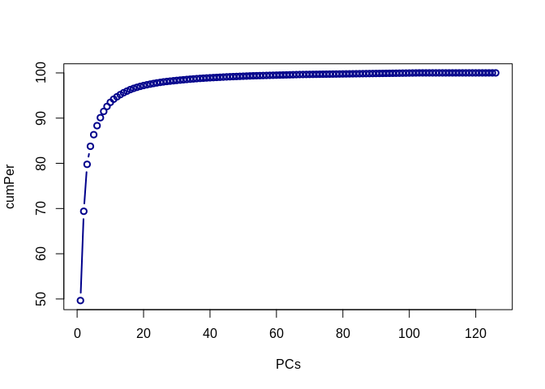

```r
comps = entire %>% select(name) %>% distinct %>% unlist()
openPrices=  entire %>% filter(name == comps[1]) %>% select(Date, Open) -> openPrices
colnames(openPrices) = c("Date", comps[1])
for(i in 2:length(comps)){
    entire %>% filter(name == comps[[i]]) %>% select(Date, Open) -> crt
    colnames(crt) = c("Date", comps[[i]])
    openPrices = full_join(openPrices, crt)
}
openPrices = openPrices %>% na.omit()
openPrices %>% select(-Date) -> openPrices
pca = prcomp(openPrices, center = T, scale. = T)
eigv = round(pca$sdev^2/sum(pca$sdev^2)*100, 2)
eigv = data.frame(c(1:126),eigv)
names(eigv) = c('PCs','Variance')
eigv %>% mutate(cumPer = cumsum(Variance)/sum(Variance) * 100) -> eigv
plot(eigv %>% select(PCs, cumPer),type = "b",col = "darkblue",lwd = 2)
```

Three first principal components sum up to almost 80% of total variance.

۶. برای هر نماد اطلاعات بخش مربوطه را از داده constituents استخراج نمایید. برای هر بخش میانگین روزانه قیمت شروع شرکت های آن را محاسبه کنید. سپس با استفاده از میانگین به دست آمده داده ایی با چند ستون که هر ستون یک بخش و هر سطر یک روز هست بسازید. داده مربوط را با داده شاخص های اقتصادی ادغام کنید. بر روی این داده pca بزنید و نمودار biplot آن را تفسیر کنید.

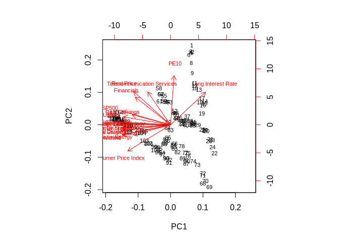

```r
sectors = stat %>% select(Sector) %>% distinct() %>% unlist()
entireWhole = entire %>% select(Open, Date, Symbol = name) %>% full_join(stat) %>% na.omit()
entireWhole %>% group_by(Sector, Date) %>% summarise(avgPrice = mean(Open)) -> res
openPrices =  res %>% filter(Sector == sectors[1])
openPrices %>% ungroup() %>% select(-Sector) -> openPrices
colnames(openPrices) = c("Date", sectors[1])
for(i in 2:length(sectors)){
    crt =  res %>% filter(Sector == sectors[i])
    crt %>% ungroup() %>% select(-Sector) -> crt
    colnames(crt) = c("Date", sectors[i])
    openPrices = crt %>% full_join(openPrices)
}
openPrices = openPrices %>% na.omit()
indexes = read_csv(paste(path, "indexes.csv", sep = "/"))
openPrices %>% full_join(indexes) %>% na.omit() -> openPricesandIndexes
pca = prcomp(openPricesandIndexes %>% select(-Date), scale. = T, center = T)
biplot(pca, cex = 0.7)
```

As we can see in the figure there is good seperability in “Long Interest Rare” and “PE10” but others are close to each other and we can not expect good seperability.

۷. روی همه اطلاعات (OHLCV) سهام اپل الگوریتم PCA را اعمال کنید. سپس از مولفه اول برای پیش بینی قیمت شروع سهام در روز آینده استفاده کنید. به سوالات سوال ۴ پاسخ دهید. آیا استفاده از مولفه اول نتیجه بهتری نسبت به داده open price برای پیش بینی قیمت دارد؟

```r
appleData = entire %>% filter(name == "AAPL") %>% select(Date, Open, High, Close, Low, Volume)
pca = prcomp(appleData %>% select(-Date), center = T, scale. = T)
appleData$comp1 = t(t(pca$rotation[,1]) %*% t(appleData %>% select(-Date)))
appleData = appleData %>% select(Date, Open, comp1)
k = 5
columns = colnames(appleData)
for (i in 1:k){
    eval(parse(text = paste0('appleData$colum', i, ' <- 0')))
    appleData[,i+3] = shift(appleData$comp1, i)
    columns[[i+3]] = paste("Daysago", i, sep = "_")
}
colnames(appleData) = columns
appleData = appleData %>% slice(k+1:n())
fit = lm(data = appleData, formula = Open ~ Daysago_1 + Daysago_2 + Daysago_3)
summary(fit)
```

```
##
## Call:
## lm(formula = Open ~ Daysago_1 + Daysago_2 + Daysago_3, data = appleData)
##
## Residuals:
##     Min      1Q  Median      3Q     Max
## -160.33 -129.73  -65.29   50.68  530.37
##
## Coefficients:
##              Estimate Std. Error t value Pr(>|t|)
## (Intercept) 1.749e+02  4.672e+00  37.445   <2e-16 ***
## Daysago_1   1.253e-06  3.896e-06   0.322    0.748
## Daysago_2   6.412e-07  4.517e-06   0.142    0.887
## Daysago_3   1.228e-06  3.897e-06   0.315    0.753
## ---
## Signif. codes:  0 '***' 0.001 '**' 0.01 '*' 0.05 '.' 0.1 ' ' 1
##
## Residual standard error: 173.7 on 4268 degrees of freedom
## Multiple R-squared:  0.0002991,  Adjusted R-squared:  -0.0004036
## F-statistic: 0.4257 on 3 and 4268 DF,  p-value: 0.7346
```

۸. نمودار سود نسبی شاخص s&p500 را رسم کنید. آیا توزیع سود نرمال است؟(از داده indexes استفاده کنید.) با استفاده از ده مولفه اول سوال پنج آیا می توانید سود و ضرر شاخص s&p500 را برای روز آينده پیش بینی کنید؟ از یک مدل رگرسیون لاجستیک استفاده کنید. درصد خطای پیش بینی را به دست آورید.

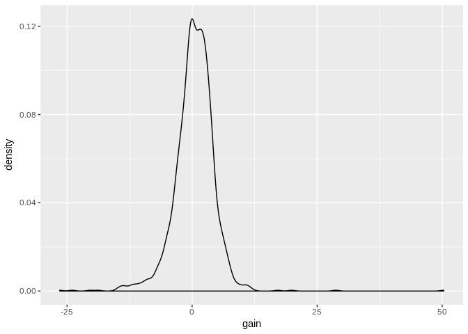

```r
SP = indexes %>% select(Date, SP500)
SP$last = shift(SP$SP500)
SP %>% mutate(gain = (SP500 - last)/last*100) %>% slice(2:n()) -> SP
ggplot(data = SP, aes(x = gain)) + geom_density()
```

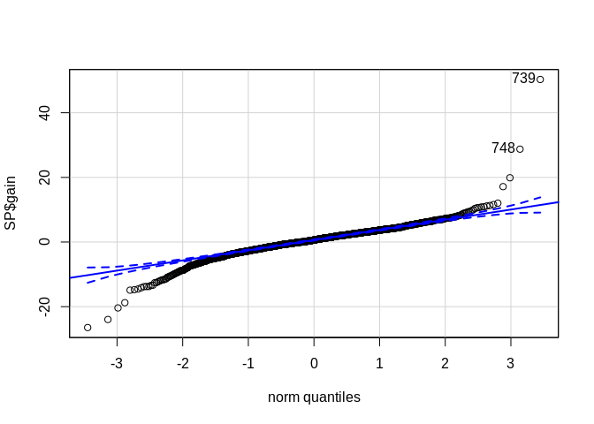

```
## [1] 739 748
```

```r
qqPlot(SP$gain)
```

```r
comps = entire %>% select(name) %>% distinct %>% unlist()
openPrices=  entire %>% filter(name == comps[1]) %>% select(Date, Open) -> openPrices
colnames(openPrices) = c("Date", comps[1])
for(i in 2:length(comps)){
    entire %>% filter(name == comps[[i]]) %>% select(Date, Open) -> crt
    colnames(crt) = c("Date", comps[[i]])
    openPrices = full_join(openPrices, crt)
}
openPrices = openPrices %>% na.omit()
pca = prcomp(openPrices %>% select(-Date), center = T, scale. = T)
featureVec = pca$rotation[,c(1:10)]
res = data.frame(t(t(featureVec) %*% t(openPrices %>% select(-Date))))
res$Date = openPrices$Date
res = full_join(res, SP %>% select(Date, gain)) %>% na.omit()
res$trainVal = shift(res$gain, 1, type = 'lead')
res = res %>% slice(1:(n()-1))
res$trainVal = ifelse(res$trainVal>=0, 1, 0)
fit = glm(data = res, formula = trainVal~PC1+PC2+PC3+PC4+PC5+PC6+PC7+PC8+PC9+PC10, family = 'binomial')
res$pred = predict.glm(fit, res, type = 'response')
res$pred = ifelse(res$pred>= 0.5, 1, 0)
prec = sum(res$pred == res$trainVal)/nrow(res) * 100
print(prec)
```

```
## [1] 100
```

۹. عکسی که در ابتدای متن آمده را در نظر بگیرید. با استفاده از pca عکس را فشرده کنید. سپس نمودار حجم عکس فشرده بر حسب تعداد مولفه اصلی را رسم کنید. بهترین انتخاب برای انتخاب تعداد مولفه ها در جهت فشرده سازی چه عددی است؟

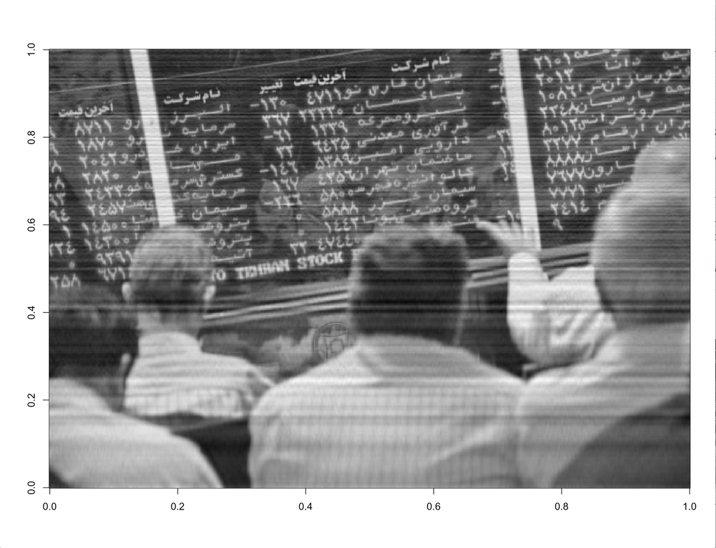

```r
library("EBImage")
pic = flip(readImage(paste(path, "stock.jpg", sep = "/")))
red.weigth   = .2989; green.weigth = .587; blue.weigth  = 0.114
img = red.weigth * imageData(pic)[,,1] +
    green.weigth * imageData(pic)[,,2] + blue.weigth  * imageData(pic)[,,3]
image(img, col = grey(seq(0, 1, length = 256)))
pca.img = prcomp(img, scale=TRUE)
chosen.components = 1:109
feature.vector = pca.img$rotation[,chosen.components]
compact.data = t(feature.vector) %*% t(img)
approx.img = t(feature.vector %*% compact.data)
# image(approx.img, col = grey(seq(0, 1, length = 256)))
```

۱۰. پنج ایده جالبی که روی داده های مالی بالا می توانستیم پیاده کنیم را بیان کنید. (ایده کافی است نیازی به محاسبه بر روی داده نیست.)

1. Best and worst days of stock market history.
2. Which months market crashes usually happen.
3. Which stock has the most price fluctuation.
4. Which stock has the biggest price crash.
5. How does holidays affect the market?